# 机器学习与因果推断 - 第一讲：课程导论

从相关性到因果性：完整讲义

作者

单位

陈志远

中国人民大学商学院

发布于

2026年3月2日

# 1 课程介绍

## 1.1 课程目标

本课程旨在培养学生运用数据回答”**为什么**”的能力，而不仅仅是”**是什么**”。在人工智能时代，机器学习擅长预测，但因果推断才能揭示机制。本课程将系统介绍：

1. **经典因果推断方法**：潜在结果框架、匹配法、双重差分、工具变量、合成控制
2. **机器学习方法**：回归、决策树、随机森林、广义随机森林、双重机器学习
3. **实际应用**：商业决策、政策评估、异质性效应分析

## 1.2 为什么要学习因果推断？

在现实商业和政策环境中，我们经常面临以下问题：

- **营销投入**真的带来了销量增长吗？还是高潜力市场本身就增长快？
- **新产品上线**提升了用户留存吗？还是忠诚用户更可能尝试新产品？
- **培训项目**提高了员工绩效吗？还是表现好的员工更可能被选中参加培训？
- **政策调整**促进了经济发展吗？还是经济本身就在周期性上行？

这些问题的核心在于区分**相关性**和**因果性**。简单比较处理组和对照组往往会得出误导性结论，因为**选择性偏误**普遍存在。

## 1.3 课程安排

| 周次 | 主题 | 内容要点 |
| --- | --- | --- |
| 1 | 课程导入 | 相关vs因果，课程框架，潜在结果框架入门 |
| 2-3 | 因果推断基础 | 潜在结果框架深入，混淆变量，识别策略 |
| 4 | 匹配法 | 倾向得分匹配，精确匹配，重叠条件 |
| 5-6 | 双重差分 | DID原理，平行趋势检验，动态效应 |
| 7 | 合成控制法 | 合成控制原理，安慰剂检验 |
| 8 | 工具变量法 | IV原理，两阶段最小二乘，排他性约束 |
| 9-10 | ML基础 | 回归，决策树，随机森林，交叉验证 |
| 11-12 | 广义随机森林 | 异质性处理效应，因果树 |
| 13 | 因果森林 | 异质性分析，Policy Learning |
| 14 | 双重机器学习 | Double ML原理，Neyman正交性 |
| 15-16 | 项目答辩 | 期末展示与点评 |

# 2 核心问题：相关 vs 因果

## 2.1 一个看似简单的例子

### 2.1.1 案例背景：新冠停特效药

某公司研发了新冠治疗特效药”新冠停”。临床数据显示：

| 城市类型 | 样本量 | 康复天数 | 标准误 |
| --- | --- | --- | --- |
| 有售卖点城市 | 5,678 | 15.3天 | 1.1 |
| 无售卖点城市 | 131,415 | 10.1天 | 2.1 |

**表面结论**：有药物的城市康复反而更慢（15.3天 vs 10.1天）！

### 2.1.2 深入分析：为什么观察结果如此反直觉？

关键洞察在于**选择机制**：

1. **药物分配非随机**：药物只在疫情*严重*的地区销售
2. **严重程度影响康复**：疫情严重地区本身康复就*慢*
3. **混淆变量**：简单比较混淆了*药物效果*和*疫情严重程度*

这是一个典型的**选择偏误**案例。接受处理的城市（有药物）与未接受处理的城市（无药物）在”疫情严重程度”这一关键维度上不可比。

## 2.2 模拟实验：Python实现

让我们用Python模拟这个场景，直观展示选择偏误是如何产生的。

### 2.2.1 数据生成过程

**点击查看完整代码**

```python
import numpy as np
import pandas as pd
import matplotlib.pyplot as plt

# 设置随机种子保证可重复性
np.random.seed(42)

# 模拟参数
n_cities = 5000  # 城市数量
true_effect = -2  # 真实药物效果：减少2天康复时间

# 步骤1：生成混淆变量（疫情严重程度）
# 假设严重程度服从标准正态分布
severity = np.random.normal(0, 1, n_cities)

# 步骤2：处理分配机制
# 严重程度 > 0 的城市获得药物（选择偏误来源）
treatment = (severity > 0).astype(int)

# 步骤3：生成结果变量（康复时间）
# 康复时间 = 基础时间 + 严重程度影响 + 药物效果 + 随机误差
recovery = 10 + severity * 3 + treatment * true_effect + np.random.normal(0, 1, n_cities)

# 创建数据框
data = pd.DataFrame({
    'severity': severity,
    'treatment': treatment,
    'recovery': recovery
})

# 显示数据前5行
print("数据预览：")
print(data.head(10))
```

```
数据预览：
   severity  treatment   recovery
0  0.496714          1   9.066383
1 -0.138264          0   9.131793
2  0.647689          1   8.147422
3  1.523030          1  12.238999
4 -0.234153          0  10.030369
5 -0.234137          0   8.023357
6  1.579213          1  13.786121
7  0.767435          1  10.790079
8 -0.469474          0   7.857344
9  0.542560          1   9.486150
```

### 2.2.2 结果分析

```python
# 计算观察到的平均康复时间
summary_stats = data.groupby('treatment')['recovery'].agg(['mean', 'std', 'count'])
summary_stats.index = ['无药物城市', '有药物城市']
print("\n观察到的统计结果：")
print(summary_stats)

# 计算观察到的"效果"
observed_effect = summary_stats.loc['有药物城市', 'mean'] - summary_stats.loc['无药物城市', 'mean']
print(f"\n观察到的差异: {observed_effect:.2f}天")
print(f"真实药物效果: {true_effect:.2f}天")
print(f"选择偏误: {observed_effect - true_effect:.2f}天")
```

```
观察到的统计结果：
            mean       std  count
无药物城市   7.610237  2.095548   2474
有药物城市  10.354289  2.061910   2526

观察到的差异: 2.74天
真实药物效果: -2.00天
选择偏误: 4.74天
```

**关键发现**：

- 观察结果显示有药物的城市康复时间**更长**（正效应）
- 但真实药物效果是**缩短**康复时间（负效应）
- 差异来源于选择偏误：疫情严重的城市才获得药物

### 2.2.3 可视化分析

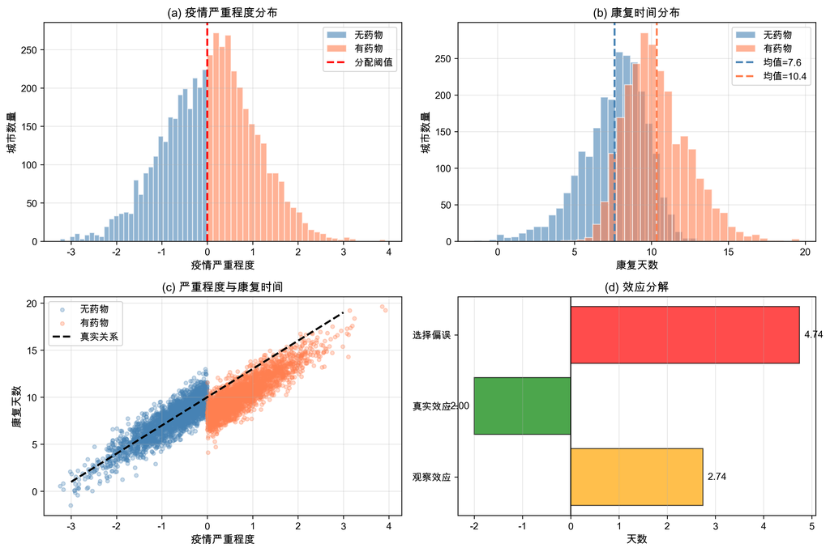

选择偏误的可视化解释

```python
fig, axes = plt.subplots(2, 2, figsize=(12, 8))

# 图1：疫情严重程度分布
axes[0, 0].hist(data[data['treatment']==0]['severity'],
                bins=30, alpha=0.6, label='无药物', color='steelblue', edgecolor='white')
axes[0, 0].hist(data[data['treatment']==1]['severity'],
                bins=30, alpha=0.6, label='有药物', color='coral', edgecolor='white')
axes[0, 0].axvline(0, color='red', linestyle='--', linewidth=2, label='分配阈值')
axes[0, 0].set_xlabel('疫情严重程度', fontsize=11)
axes[0, 0].set_ylabel('城市数量', fontsize=11)
axes[0, 0].set_title('(a) 疫情严重程度分布', fontsize=12, fontweight='bold')
axes[0, 0].legend()
axes[0, 0].grid(alpha=0.3)

# 图2：康复时间分布
axes[0, 1].hist(data[data['treatment']==0]['recovery'],
                bins=30, alpha=0.6, label='无药物', color='steelblue', edgecolor='white')
axes[0, 1].hist(data[data['treatment']==1]['recovery'],
                bins=30, alpha=0.6, label='有药物', color='coral', edgecolor='white')
axes[0, 1].axvline(data[data['treatment']==0]['recovery'].mean(),
                   color='steelblue', linestyle='--', linewidth=2, label=f'均值={data[data["treatment"]==0]["recovery"].mean():.1f}')
axes[0, 1].axvline(data[data['treatment']==1]['recovery'].mean(),
                   color='coral', linestyle='--', linewidth=2, label=f'均值={data[data["treatment"]==1]["recovery"].mean():.1f}')
axes[0, 1].set_xlabel('康复天数', fontsize=11)
axes[0, 1].set_ylabel('城市数量', fontsize=11)
axes[0, 1].set_title('(b) 康复时间分布', fontsize=12, fontweight='bold')
axes[0, 1].legend()
axes[0, 1].grid(alpha=0.3)

# 图3：严重程度与康复时间的关系
axes[1, 0].scatter(data[data['treatment']==0]['severity'],
                   data[data['treatment']==0]['recovery'],
                   alpha=0.3, s=15, color='steelblue', label='无药物')
axes[1, 0].scatter(data[data['treatment']==1]['severity'],
                   data[data['treatment']==1]['recovery'],
                   alpha=0.3, s=15, color='coral', label='有药物')
# 添加趋势线
x_range = np.linspace(-3, 3, 100)
axes[1, 0].plot(x_range, 10 + 3*x_range, 'k--', linewidth=2, label='真实关系')
axes[1, 0].set_xlabel('疫情严重程度', fontsize=11)
axes[1, 0].set_ylabel('康复天数', fontsize=11)
axes[1, 0].set_title('(c) 严重程度与康复时间', fontsize=12, fontweight='bold')
axes[1, 0].legend()
axes[1, 0].grid(alpha=0.3)

# 图4：效应分解
ax = axes[1, 1]
effects = [observed_effect, true_effect, observed_effect - true_effect]
colors = ['orange', 'green', 'red']
labels = ['观察效应', '真实效应', '选择偏误']
bars = ax.barh(labels, effects, color=colors, alpha=0.7, edgecolor='black')
ax.axvline(0, color='black', linewidth=1)
ax.set_xlabel('天数', fontsize=11)
ax.set_title('(d) 效应分解', fontsize=12, fontweight='bold')
ax.grid(alpha=0.3, axis='x')

# 添加数值标签
for bar, val in zip(bars, effects):
    ax.text(val + 0.1 if val >= 0 else val - 0.1, bar.get_y() + bar.get_height()/2,
            f'{val:.2f}', ha='left' if val >= 0 else 'right', va='center', fontweight='bold')

plt.tight_layout()
plt.show()
```

### 2.2.4 图形解读

1. **图(a)**：有药物的城市（红色）集中在严重程度>0的区域，而无药物的城市（蓝色）集中在严重程度<0的区域。两组在混淆变量上分布完全不同。
2. **图(b)**：有药物城市的康复时间均值反而更高，但这只是因为它们疫情更严重，而非药物无效。
3. **图(c)**：散点图显示严重程度与康复时间正相关。两组数据的分离导致了观察偏误。
4. **图(d)**：效应分解显示观察效应（正）= 真实效应（负）+ 选择偏误（正且很大）。

## 2.3 R语言验证

同样的分析可以用R语言实现，结果应完全一致（数值可能因随机数生成器差异而略有不同）。

```r
#| eval: true
#| echo: true
#| message: false
#| warning: false

library(tidyverse)

# 设置随机种子
set.seed(42)

# 模拟参数
n <- 5000
true_effect <- -2

# 生成数据
data_r <- tibble(
  severity = rnorm(n),
  treatment = ifelse(severity > 0, 1, 0),
  recovery = 10 + severity * 3 + treatment * true_effect + rnorm(n)
)

# 计算统计量
summary_r <- data_r |>
  group_by(treatment) |>
  summarise(
    mean_recovery = mean(recovery),
    sd_recovery = sd(recovery),
    n = n()
  )

print("R语言统计结果：")
print(summary_r)

# 计算效应
observed_effect_r <- summary_r$mean_recovery[2] - summary_r$mean_recovery[1]
cat("\n观察到的差异:", round(observed_effect_r, 2), "天\n")
cat("真实药物效果:", true_effect, "天\n")
cat("选择偏误:", round(observed_effect_r - true_effect, 2), "天\n")
```

[output not shown]

# 3 潜在结果框架

## 3.1 核心概念

### 3.1.1 潜在结果的定义

Rubin因果模型的核心思想是：每个个体都有**两种潜在状态**：

- $Y_i(1)$：个体$i$接受处理时的结果（潜在结果1）
- $Y_i(0)$：个体$i$未接受处理时的结果（潜在结果0）

**关键问题**：对于任何个体，我们只能观察到其中一种状态！这被称为**因果推断的基本问题**。

### 3.1.2 因果效应的定义

个体$i$的处理效应（Individual Treatment Effect, ITE）定义为：

$$\tau_i = Y_i(1) - Y_i(0)$$

由于无法同时观测两种状态，个体层面的因果效应**不可识别**。

## 3.2 观察到的结果

我们实际能观测到的结果可以用以下公式表示：

$$Y_i = \begin{cases} Y_i(1) & \text{if } D_i = 1 \text{（接受处理）} \\ Y_i(0) & \text{if } D_i = 0 \text{（未接受处理）} \end{cases}$$

等价地写成：

$$Y_i = Y_i(0) + D_i \times [Y_i(1) - Y_i(0)] = Y_i(0) + D_i \times \tau_i$$

这被称为**Rubin因果模型**的基本方程。

## 3.3 平均处理效应

由于个体效应不可识别，我们转而关注**总体参数**：

### 3.3.1 平均处理效应（ATE）

$$\text{ATE} = E[Y_i(1) - Y_i(0)] = E[\tau_i]$$

ATE表示如果随机选择一个人给予处理，预期效果是多少。

### 3.3.2 处理组平均处理效应（ATT）

$$\text{ATT} = E[Y_i(1) - Y_i(0) | D_i = 1]$$

ATT表示实际接受处理的人群从中获益多少，这在政策评估中往往更有意义。

## 3.4 选择性偏误的数学分解

观察到的组间差异可以分解为：

$$\underbrace{E[Y|D=1] - E[Y|D=0]}_{\text{观察差异}} = \underbrace{E[Y(1)-Y(0)|D=1]}_{\text{ATT}} + \underbrace{E[Y(0)|D=1] - E[Y(0)|D=0]}_{\text{选择偏误}}$$

### 3.4.1 分解的直观解释

| 成分 | 含义 | 示例 |
| --- | --- | --- |
| **观察差异** | 简单比较两组均值 | 参加培训者收入 - 未参加者收入 |
| **ATT** | 处理对接受者的真实效应 | 培训使收入提高1000元 |
| **选择偏误** | 接受者的”先天优势” | 参加培训者本来能力就更强 |

**核心问题**：选择偏误往往为正（能力强的人更可能接受处理），导致简单比较高估处理效应。

## 3.5 随机实验：因果推断的黄金标准

### 3.5.1 随机化的魔力

如果处理分配$D$是完全随机的，则：

$$D \perp\!\!\perp Y(0), Y(1)$$

这意味着：

$$E[Y(0)|D=1] = E[Y(0)|D=0]$$

选择偏误消失了！此时：

$$\underbrace{E[Y|D=1] - E[Y|D=0]}_{\text{观察差异}} = \underbrace{E[Y(1)-Y(0)]}_{\text{ATE}}$$

### 3.5.2 随机实验为什么有效？

1. **平衡性**：随机化保证处理组和对照组在**所有可观测和不可观测特征**上分布相同
2. **可忽略性**：$D$的分配不依赖于潜在结果
3. **无混淆**：不存在同时影响$D$和$Y$的变量

### 3.5.3 现实中的挑战

虽然随机实验是”黄金标准”，但现实中往往不可行：

- **伦理问题**：不能随机分配吸烟或不吸烟
- **成本问题**：大规模随机实验可能极其昂贵
- **可行性**：某些处理无法随机分配（如性别、种族）

因此，我们需要**观察性研究方法**来模拟随机实验的条件。

# 4 更多”相关≠因果”的陷阱

## 4.1 常见混淆类型

### 4.1.1 1. 反向因果（Reverse Causality）

**例子**：警察越多的地区犯罪率越高

**解释**：可能是犯罪率高的地区才部署更多警察，而非警察导致犯罪

**数学表达**：$Y \rightarrow D$ 而非 $D \rightarrow Y$

### 4.1.2 2. 共同原因（Common Cause）

**例子**：冰淇淋销量与溺水事故正相关

**解释**：气温升高同时导致冰淇淋消费增加和游泳活动增加

**数学表达**：$Z \rightarrow D$ 且 $Z \rightarrow Y$，导致$Corr(D,Y) \neq 0$即使$D$对$Y$无因果效应

### 4.1.3 3. 选择偏差（Selection Bias）

**例子**：名校毕业生收入更高

**解释**：能力强的学生更可能进入名校，也更可能获得高收入

**核心问题**：样本选择非随机，处理组和对照组不可比

## 4.2 代码模拟：三种偏误

**点击查看三种偏误的模拟代码**

```python
np.random.seed(42)
n = 3000

# ========== 场景1：反向因果 ==========
# 真实因果：犯罪率 → 警察数量（而非相反）
crime_rate = np.random.normal(0, 1, n)  # 犯罪率（标准化）
police = 5 + 2 * crime_rate + np.random.normal(0, 0.5, n)  # 警察数量

# 观察到的相关性
observed_corr_reverse = np.corrcoef(police, crime_rate)[0, 1]

# ========== 场景2：共同原因（混淆变量）==========
temperature = np.random.normal(25, 5, n)  # 气温
ice_cream = 100 + 5 * temperature + np.random.normal(0, 10, n)  # 冰淇淋销量
drowning = 2 + 0.3 * temperature + np.random.normal(0, 0.5, n)  # 溺水事故

observed_corr_confound = np.corrcoef(ice_cream, drowning)[0, 1]

# ========== 场景3：选择偏差 ==========
ability = np.random.normal(0, 1, n)  # 能力（不可观测的混淆变量）
# 能力强的人更可能进入名校
elite_school = (ability + np.random.normal(0, 0.5, n) > 0).astype(int)
# 能力强的人收入更高
income = 5000 + 1000 * ability + 500 * elite_school + np.random.normal(0, 500, n)

# 观察到的"名校效应"
elite_income = income[elite_school == 1].mean()
nonelite_income = income[elite_school == 0].mean()
observed_school_effect = elite_income - nonelite_income

print("=" * 60)
print("三种相关≠因果的场景模拟")
print("=" * 60)
print(f"\n【反向因果】警察与犯罪率的相关系数: {observed_corr_reverse:.3f}")
print("   解释：并非警察导致犯罪，而是犯罪多→部署更多警察")

print(f"\n【共同原因】冰淇淋销量与溺水事故的相关系数: {observed_corr_confound:.3f}")
print("   解释：气温同时影响两者，而非冰淇淋导致溺水")

print(f"\n【选择偏差】名校 vs 普通学校收入差异: {observed_school_effect:.0f}元")
print("   解释：部分差异来自能力（能力强的人更可能进名校）")
```

```
============================================================
三种相关≠因果的场景模拟
============================================================

【反向因果】警察与犯罪率的相关系数: 0.969
   解释：并非警察导致犯罪，而是犯罪多→部署更多警察

【共同原因】冰淇淋销量与溺水事故的相关系数: 0.886
   解释：气温同时影响两者，而非冰淇淋导致溺水

【选择偏差】名校 vs 普通学校收入差异: 1937元
   解释：部分差异来自能力（能力强的人更可能进名校）
```

### 4.2.1 可视化三种偏误

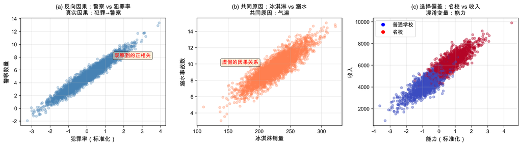

三种常见偏误的可视化

```python
fig, axes = plt.subplots(1, 3, figsize=(14, 4))

# 图1：反向因果
axes[0].scatter(crime_rate, police, alpha=0.3, s=20, color='steelblue')
axes[0].set_xlabel('犯罪率（标准化）', fontsize=11)
axes[0].set_ylabel('警察数量', fontsize=11)
axes[0].set_title('(a) 反向因果：警察 vs 犯罪率\n真实因果：犯罪→警察', fontsize=11, fontweight='bold')
axes[0].grid(alpha=0.3)

# 添加注释
axes[0].annotate('观察到的正相关', xy=(1.5, 8), fontsize=10, color='red',
                bbox=dict(boxstyle='round', facecolor='wheat', alpha=0.5))

# 图2：共同原因
axes[1].scatter(ice_cream, drowning, alpha=0.3, s=20, color='coral')
axes[1].set_xlabel('冰淇淋销量', fontsize=11)
axes[1].set_ylabel('溺水事故数', fontsize=11)
axes[1].set_title('(b) 共同原因：冰淇淋 vs 溺水\n共同原因：气温', fontsize=11, fontweight='bold')
axes[1].grid(alpha=0.3)

# 添加注释
axes[1].annotate('虚假的因果关系', xy=(140, 10), fontsize=10, color='red',
                bbox=dict(boxstyle='round', facecolor='wheat', alpha=0.5))

# 图3：选择偏差
axes[2].scatter(ability, income, c=elite_school, cmap='coolwarm', alpha=0.4, s=20)
axes[2].set_xlabel('能力（标准化）', fontsize=11)
axes[2].set_ylabel('收入', fontsize=11)
axes[2].set_title('(c) 选择偏差：名校 vs 收入\n混淆变量：能力', fontsize=11, fontweight='bold')
axes[2].grid(alpha=0.3)

# 添加图例
from matplotlib.lines import Line2D
legend_elements = [Line2D([0], [0], marker='o', color='w', markerfacecolor='blue',
                          markersize=8, label='普通学校'),
                   Line2D([0], [0], marker='o', color='w', markerfacecolor='red',
                          markersize=8, label='名校')]
axes[2].legend(handles=legend_elements, loc='upper left')

plt.tight_layout()
plt.show()
```

## 4.3 关键启示

在观察性研究中，简单比较两组均值是危险的！我们必须考虑：

1. **处理组和对照组是否可比？**
   - 在协变量分布上是否相似？
   - 是否存在系统性差异？
2. **是否存在混杂变量？**
   - 同时影响处理分配和结果的变量
   - 如何识别和测量这些变量？
3. **如何处理选择偏误？**
   - 匹配法：找到可比的子样本
   - 双重差分：利用时间变化
   - 工具变量：找到”准实验”变化
   - 回归控制：统计上调整混淆变量

这正是因果推断方法要解决的问题！

# 5 课程方法预览

## 5.1 我们将学习的方法

本课程涵盖两大类方法：

### 5.1.1 经典因果推断方法（前8周）

这些方法源自经济学和统计学的长期发展：

1. **匹配法（Matching）**
   - 倾向得分匹配（PSM）
   - 精确匹配和共同支持
   - 重叠条件和平衡检验
2. **双重差分（Difference-in-Differences, DID）**
   - 经典DID模型
   - 平行趋势假设
   - 交错DID和动态效应
3. **工具变量（Instrumental Variables, IV）**
   - 两阶段最小二乘法（2SLS）
   - 排他性约束和弱工具变量检验
   - LATE（局部平均处理效应）
4. **合成控制法（Synthetic Control）**
   - 构造合成对照组
   - 安慰剂检验
   - 多期处理

### 5.1.2 机器学习方法（后6周）

这些方法将ML的预测能力与因果推断结合：

1. **广义随机森林（Generalized Random Forests）**
   - 异质性处理效应估计
   - 置信区间构造
2. **因果森林（Causal Forests）**
   - 发现处理效应的异质性
   - Policy Learning
3. **双重机器学习（Double Machine Learning）**
   - Neyman正交性
   - 高维控制变量
   - 去偏估计

## 5.2 学习路径

对于每种方法，我们将遵循以下学习路径：

1. **理解原理**
   - 识别假设：什么条件下方法有效？
   - 直观解释：为什么方法有效？
2. **掌握应用**
   - 适用场景：什么时候用？
   - 实施步骤：怎么用？
   - 稳健性检验：结果可靠吗？
3. **代码实现**
   - Python实现（scikit-learn, econml, doubleml）
   - R实现（MatchIt, fixest, grf）
4. **批判思考**
   - 方法局限性：什么情况下不能用？
   - 替代方法：还有其他选择吗？
   - 实际应用：文献中的案例

# 6 交互式参数探索

## 6.1 模拟参数的影响

让我们系统探索不同参数对选择偏误的影响：

**参数探索代码**

```python
def simulate_bias(n_cities=5000, true_drug_effect=-2.0, confound_strength=3.0, threshold=0):
    """
    模拟选择偏误

    Parameters:
    -----------
    n_cities : int
        城市数量
    true_drug_effect : float
        真实药物效果（负值表示缩短康复时间）
    confound_strength : float
        混淆变量的影响强度
    threshold : float
        处理分配阈值（严重程度>threshold获得药物）

    Returns:
    --------
    dict : 包含观察效应、真实效应、选择偏误的字典
    """
    severity = np.random.normal(0, 1, n_cities)
    treatment = (severity > threshold).astype(int)
    recovery = 10 + severity * confound_strength + treatment * true_drug_effect + np.random.normal(0, 1, n_cities)

    data = pd.DataFrame({
        'severity': severity,
        'treatment': treatment,
        'recovery': recovery
    })

    control_mean = data[data['treatment'] == 0]['recovery'].mean()
    treated_mean = data[data['treatment'] == 1]['recovery'].mean()
    observed_effect = treated_mean - control_mean
    selection_bias = observed_effect - true_drug_effect

    return {
        'observed_effect': observed_effect,
        'true_effect': true_drug_effect,
        'selection_bias': selection_bias,
        'treatment_rate': treatment.mean()
    }

# 参数敏感性分析
np.random.seed(42)

print("=" * 70)
print("参数敏感性分析：混淆强度对选择偏误的影响")
print("=" * 70)

confound_values = [0, 1, 2, 3, 4, 5]
results = []

for cs in confound_values:
    np.random.seed(42)  # 固定种子保证可比性
    result = simulate_bias(confound_strength=cs)
    results.append(result)
    print(f"\n混淆强度 = {cs}:")
    print(f"  观察效应: {result['observed_effect']:+.2f}天")
    print(f"  真实效应: {result['true_effect']:+.2f}天")
    print(f"  选择偏误: {result['selection_bias']:+.2f}天")
    print(f"  处理率: {result['treatment_rate']*100:.1f}%")
```

```
======================================================================
参数敏感性分析：混淆强度对选择偏误的影响
======================================================================

混淆强度 = 0:
  观察效应: -2.02天
  真实效应: -2.00天
  选择偏误: -0.02天
  处理率: 50.5%

混淆强度 = 1:
  观察效应: -0.43天
  真实效应: -2.00天
  选择偏误: +1.57天
  处理率: 50.5%

混淆强度 = 2:
  观察效应: +1.15天
  真实效应: -2.00天
  选择偏误: +3.15天
  处理率: 50.5%

混淆强度 = 3:
  观察效应: +2.74天
  真实效应: -2.00天
  选择偏误: +4.74天
  处理率: 50.5%

混淆强度 = 4:
  观察效应: +4.33天
  真实效应: -2.00天
  选择偏误: +6.33天
  处理率: 50.5%

混淆强度 = 5:
  观察效应: +5.92天
  真实效应: -2.00天
  选择偏误: +7.92天
  处理率: 50.5%
```

### 6.1.1 结果解读

**关键发现**：

- 当`confound_strength=0`时，无选择偏误，观察效应=真实效应
- 随着混淆强度增加，选择偏误急剧增大
- 即使真实效应为负（药物有效），强混淆可能导致观察效应为正（看似无效甚至有害）

## 6.2 可视化参数影响

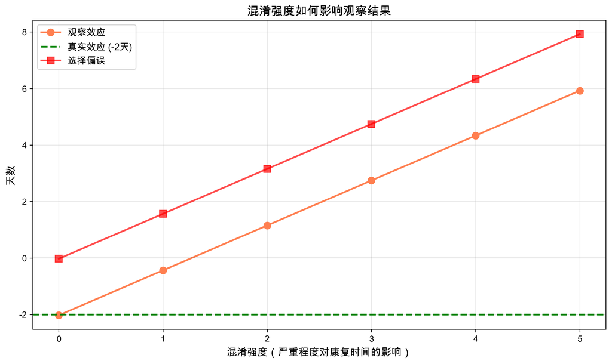

混淆强度对选择偏误的影响

```python
fig, ax = plt.subplots(figsize=(10, 6))

confound_values = [0, 1, 2, 3, 4, 5]
observed_effects = [r['observed_effect'] for r in results]
selection_biases = [r['selection_bias'] for r in results]

ax.plot(confound_values, observed_effects, 'o-', linewidth=2, markersize=8,
        label='观察效应', color='coral')
ax.axhline(y=-2, color='green', linestyle='--', linewidth=2, label='真实效应 (-2天)')
ax.plot(confound_values, selection_biases, 's-', linewidth=2, markersize=8,
        label='选择偏误', color='red', alpha=0.7)

ax.set_xlabel('混淆强度（严重程度对康复时间的影响）', fontsize=12)
ax.set_ylabel('天数', fontsize=12)
ax.set_title('混淆强度如何影响观察结果', fontsize=14, fontweight='bold')
ax.legend(fontsize=11)
ax.grid(alpha=0.3)
ax.axhline(y=0, color='black', linewidth=0.5)

plt.tight_layout()
plt.show()
```

**政策含义**：

- 在混淆变量影响强的领域（如医疗、教育），简单比较极其危险
- 必须采用因果推断方法才能获得有效结论
- 干预前评估混淆变量强度是研究设计的关键步骤

# 7 总结

## 7.1 本讲要点回顾

### 7.1.1 1. 课程定位

- **机器学习**：关注预测（是什么）
- **因果推断**：关注归因（为什么）
- **结合**：AI时代的科学决策能力

### 7.1.2 2. 核心问题：相关性 ≠ 因果性

- **混淆变量**：同时影响处理和结果
- **选择偏误**：处理组和对照组不可比
- **反向因果**：结果影响处理分配

### 7.1.3 3. 分析框架：潜在结果模型

- 每个个体有两种”潜在”状态
- **因果推断的基本问题**：无法同时观测
- **随机实验**：通过随机化消除选择偏误

### 7.1.4 4. 学习内容概览

- **经典方法**：匹配、DID、IV、合成控制
- **前沿方法**：因果森林、双重机器学习
- **实践应用**：真实案例分析

## 7.2 关键公式汇总

| 概念 | 公式 | 说明 |
| --- | --- | --- |
| 个体处理效应 | $\tau_i = Y_i(1) - Y_i(0)$ | 不可观测 |
| 平均处理效应 | $\text{ATE} = E[Y(1) - Y(0)]$ | 目标参数 |
| 观察差异分解 | $E[Y \mid D=1] - E[Y \mid D=0] = \text{ATT} + \text{选择偏误}$ | 偏误来源 |
| 随机化条件 | $D \perp\!\!\perp Y(0), Y(1)$ | 无偏估计 |

## 7.3 下一讲预告

**第二讲：因果推断基础——潜在结果框架深入**

- 条件独立假设（CIA）
- 重叠条件（Overlap）
- 识别 vs 估计
- 反事实预测的机器学习方法

## 7.4 课后思考

1. **在你的研究领域**，找到一个”相关≠因果”的例子。混淆变量可能是什么？
2. **随机实验的局限**：为什么有些重要问题无法通过随机实验回答？观察性研究的价值是什么？
3. **AI与因果推断**：大语言模型能帮助我们做因果推断吗？其局限性在哪里？

**联系方式**

- 邮箱：chenzhiyuan@rmbs.ruc.edu.cn
- 办公室：919
- Office Hours：周四下午2-3点

*本讲义基于 Scott Cunningham《Causal Inference: The Mixtape》、Angrist & Pischke《Mostly Harmless Econometrics》以及 Chernozhukov 等的《Applied Causal Inference Powered by ML and AI》整理而成。*